# A Computational Social Science exercise: Mapping the US political community

Alessio Nardin

01/05/2022

## Goal

This CSS exercise aims to showcase a strategy to analyze the structure of a political network in a Social Media platform, Twitter. During the analysis are used different methods ranging from network analysis, sentiment analysis, and simple statistics.

The exercise is divided in different sections that explain each steps for reproducibility.

## Data selection and collection

The overall structure of the US political community makes it a good example for a beginner analysis of CSS.

The research questions that will be tackled include:

- Is the division between political parties reflected in the Twitter community?
- What are the relationships between members of the same party and with members of other affiliations?
- Was there any interaction between members during the period taken in exam?

## A few words on Twitter

Twitter is commonly used as a means of communication for reaching to the electorate and shaping the public discussion; there is a broad literature treating the political usage of social media.

### Sample examined

As of the 1st May 2020, the Senate was formed by 100 Senators, and the House of Representatives of 436 Representatives out of 441 (5 seats are currently vacant). I included in the Presidential Cabinet the 23 Cabinet members, the President, and the First Lady. Even if it is not formally an elected official, the first lady should be included because of the diplomatic roles it has acquired informally in civil society.

## Data recollection

First I collected information regarding names, political affiliations, and class (Senate, House of Representatives, or Presidential cabinet) from the official websites of the House of Representatives, the Senate, and the White House using Python and beautifulsoup[^1]. I combined the information in a table called pol_data.csv that I imported on RStudio.

I found 536 accounts for the Congress and 25 for the Presidential cabinet. Every individual in the population possessed at least one Twitter account. Some members possessed multiple accounts and in those cases I decided to include only the official ones, except for the President and the Vice President of the United States, reaching a total account number of 563.

### Formatting the data to adapt it to our needs

At present, I have a table pol_data with the following columns:

```r
head(sample_n(pol_info, 5))
```

```
##                    name     screen_name class       role party
## 121       garret graves repgarretgraves     R  louisiana     R
## 394 jeffrey fortenberry jefffortenberry     R   nebraska     R
## 281         kim schrier   repkimschrier     R washington     D
## 31           jon tester   senatortester     S    montana     D
## 192       brian higgins repbrianhiggins     R   new york     D
```

I have another table containing data that describe whether an account follows another (friendship relationship). In Twitter, at the time of data collection, this kind of relationship can be modeled into a directed graph, where each account forms a node which is connected to other nodes through directed unweighted edges.

Since this is only an exercise which aims to showcase some possible approaches to analyzing how political actors behave in social media, I decided to filter out the accounts different to the original sample so that the analysis could focus on the internal relationship in the political community. I did so by excluding the nodes of the network which had an out-degree equal to zero. I then added to the network the one account belonging to the political community which did not follow anybody.

```r
pol_network<-graph.data.frame(pol_edgelist)

#calculate out degree
V(pol_network)$outdegree<-degree(pol_network, mode = "out")

#create subgraph
pol_network_tidy<-induced.subgraph(pol_network, vids = (V(pol_network)$outdegree > 0))

#repmarshall is excluded because he doesn't follow anybody
edges_marshall<-pol_edgelist[which(pol_edgelist$V2 == "repmarshall"),]

#add missing node
pol_network_tidy<-pol_network_tidy + "repmarshall"

#add missing edge
friends_network<-pol_network_tidy + edges(edges_marshall$V1, edges_marshall$V2)

#using simplify function to get rid of loops
friends_network<-simplify(friends_network)

#export edges
edges<-igraph::as_data_frame(friends_network)

#export nodes to add attributes
nodes<-data.frame(V(friends_network)$name, V(friends_network)$name)

#rename to perform inner join
colnames(nodes)<-c("Id", "screen_name")

#inner join
nodes<-inner_join(nodes, pol_info, by = "screen_name")

#recreate graph
friends_network<-graph.data.frame(edges, vertices = nodes)
```

# Social Network analysis

#### Degree

To map a community, centrality measures can help understand the relationships between the different actors. One of the most used measures is the degree, which simply counts the number of relationships each actors has with the other members of the sample. The degree can measure both incoming and departing relationships (indegree, outdegree).

By applying this technique to our data, a node with a high in-degree is followed by a large number of accounts. Conversely, a high out-degree suggests that the account follows large number of accounts. To improve the statistical significance of the measure, I divided the nodes in twenty chunks depending on their degree, and I calculated the main centrality measures for all the three distributions.

```r
#calculate degree
V(pol_network_tidy)$totdegree<-degree(pol_network_tidy, mode = "all")
V(pol_network_tidy)$indegree<-degree(pol_network_tidy, mode = "in")
V(pol_network_tidy)$outdegree<-degree(pol_network_tidy, mode = "out")

#create reference df
network_info<-as.tibble(vertex.attributes(pol_network_tidy))

#divide degree in discrete fields
network_info$discrete_indegree<-
  discretize(V(pol_network_tidy)$indegree,
             method = "interval", breaks = 20)

network_info$discrete_outdegree<-
  discretize(V(pol_network_tidy)$outdegree,
             method = "interval", breaks = 20)

network_info$discrete_totdegree<-
  discretize(V(pol_network_tidy)$totdegree,
             method = "interval", breaks = 20)

#create dataframes containing division in discrete fields
range_indegree<-data.frame(table(network_info$discrete_indegree))
range_outdegree<-data.frame(table(network_info$discrete_outdegree))
range_totdegree<-data.frame(table(network_info$discrete_totdegree))

#create dataframe containing the modes of the three distributions
le_mode<-t(data.frame(range_indegree$Var1[which.max(range_indegree$Freq)],
          range_outdegree$Var1[which.max(range_outdegree$Freq)],
          range_totdegree$Var1[which.max(range_totdegree$Freq)]))

#calculating centrality measures of the three distributions
outdegree<-c(mean(V(pol_network_tidy)$outdegree),
             quantile(V(pol_network_tidy)$outdegree),
             sd(network_info$outdegree),
             var(network_info$outdegree))

indegree<-c(mean(V(pol_network_tidy)$indegree),
             quantile(V(pol_network_tidy)$indegree),
              sd(network_info$indegree),
                var(network_info$indegree))

totdegree<-c(mean(V(pol_network_tidy)$totdegree),
            quantile(V(pol_network_tidy)$totdegree),
            sd(network_info$totdegree),
            var(network_info$totdegree))

#bind dataframes together to build a comprehensive table
degree<-data.frame(rbind(indegree, outdegree, totdegree))
degree<-cbind(degree, le_mode)

#rename columns
colnames(degree)<-c("Mean", "0%", "25%", "50%", "75%", "100%", "St.Dev.","Variance","Mode")

#round results
degree$Mean<-round(degree$Mean, digits = 2)
degree$St.Dev.<-round(degree$St.Dev., digits = 2)
degree$Variance<-round(degree$Variance, digits = 2)

#clean text of mode column
degree$Mode<-gsub("\\[", "", degree$Mode)
degree$Mode<-gsub(")", "", degree$Mode)
degree$Mode<-gsub(",", "-", degree$Mode)
```

```
##             Mean 0%   25% 50%   75% 100% St.Dev. Variance     Mode
## indegree  133.38  0 109.5 139 163.5  350   48.73  2374.53  140-158
## outdegree 133.38  0  64.0 117 191.0  522   92.75  8602.14 78.3-104
## totdegree 266.76  1 184.5 256 347.0  682  121.53 14769.52  205-239
```

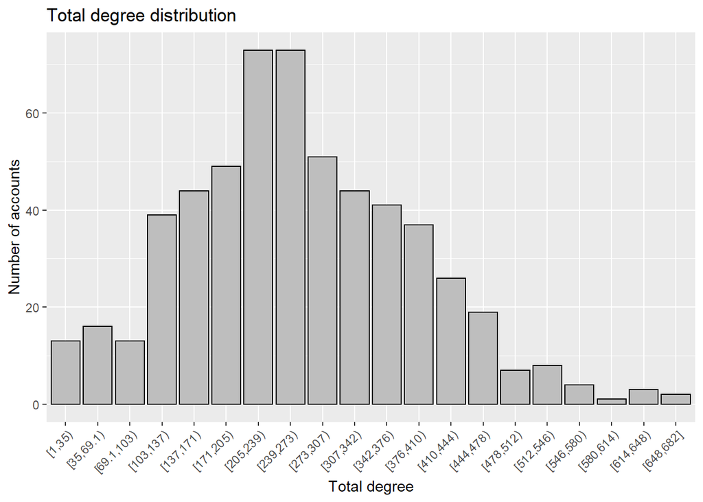

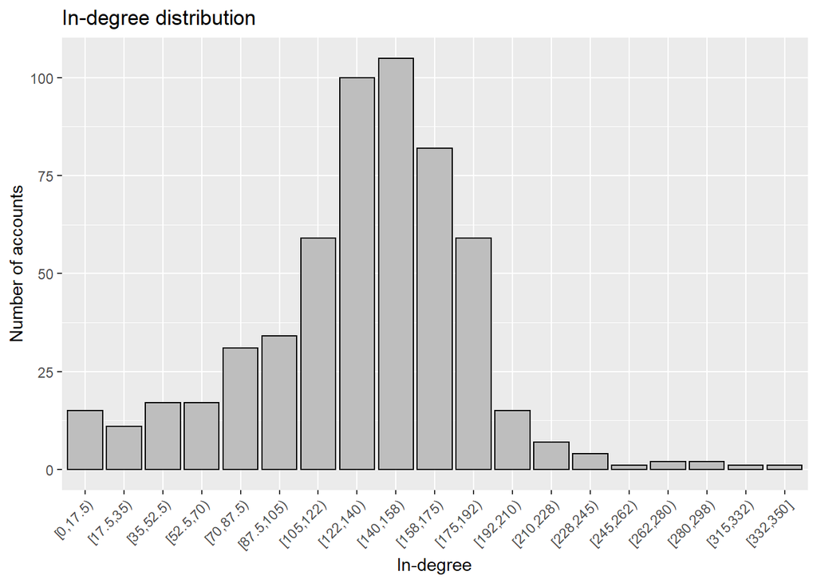

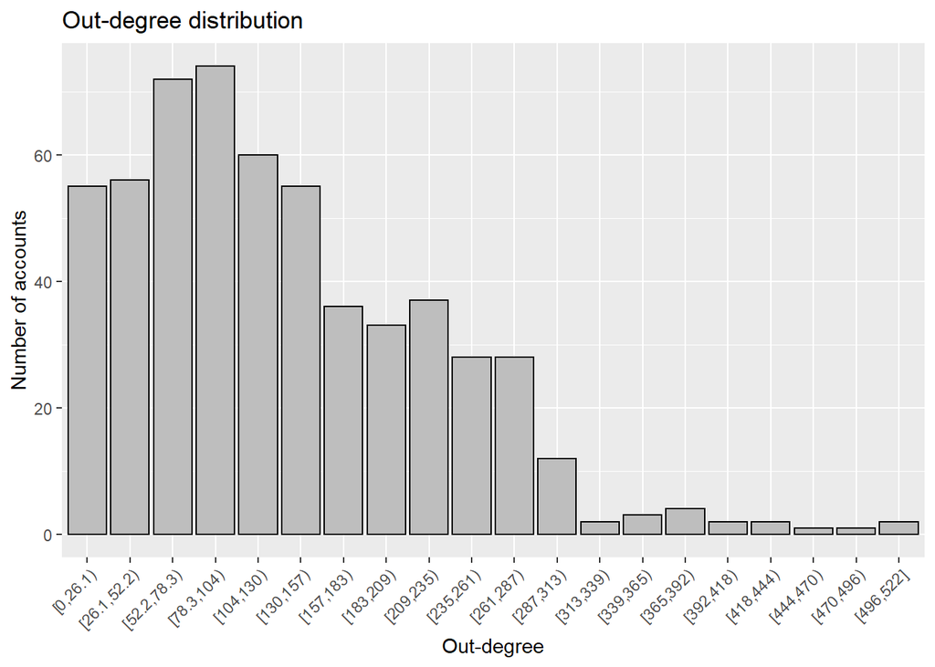

The in-degree distribution has a lower standard deviation that the out-degree distribution.

### In-degree

Since I am interested in the most influential people in the network, I decided to check on the outliers of the in-degree distribution. Logically, they should be individuals that fulfill important roles within the US political sphere. Here they are:

```
##               name     screen_name class party indegree
## 26      mike pence              vp     P     R      350
## 2     donald trump           potus     P     R      328
## 1     donald trump realdonaldtrump     P     R      295
## 149   nancy pelosi   speakerpelosi     R     D      291
## 159 kevin mccarthy       gopleader     R     R      273
## 3    melania trump          flotus     P     R      263
## 448    steny hoyer     leaderhoyer     R     D      254
```

These accounts are characterized by having a large number of followers compared to the remaining population. This can be partly explained by the fact that the office assumed by these specific individuals is particularly important and therefore a higher number of officials are interested in following their tweets.

As can be seen in the table above, 4 out of 7 positions are covered by the President of the United States, the Vice-President, and the First Lady. The remaining three positions are covered by prominent members of the House of Representatives, namely the Speaker of the House (Nancy Pelosi), the House minority leader (Kevin McCarthy), and the House majority leader (Steny Hoyer).

### Countercheck: in-degree out-degree relationship

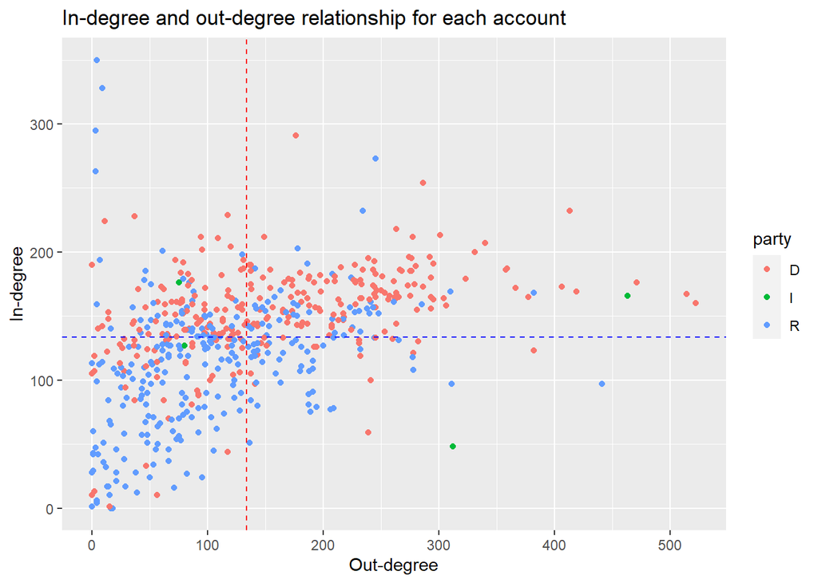

The accounts with the highest in-degree possess a low out-degree.

[^1]: the extent of the data recollection method exceed the ones of this exercise